# carPricePrediction

```python
# importing necessary libraries
import matplotlib.pyplot as plt # matplotlib for plotting and figures plot
import pandas as pd  # pandas for data frame
import seaborn as sns # seaborn for heatmap, countplot, boxplot
import numpy as np # numpy for array, matrix calculations
import warnings
warnings.filterwarnings('ignore') # to ignore all warning
```

```python
#__version__ to check versions of libraries
import matplotlib
np.__version__, pd.__version__, sns.__version__, matplotlib.__version__
```

```
('2.1.3', '2.2.3', '0.13.2', '3.10.0')
```

```python
# reading csv file through pandas
df = pd.read_csv('Cars.csv')
df
```

|  | name | year | selling_price | km_driven | fuel | seller_type | transmission | owner | mileage | engine | max_power | torque | seats |
| --- | --- | --- | --- | --- | --- | --- | --- | --- | --- | --- | --- | --- | --- |
| 0 | Maruti Swift Dzire VDI | 2014 | 450000 | 145500 | Diesel | Individual | Manual | First Owner | 23.4 kmpl | 1248 CC | 74 bhp | 190Nm@ 2000rpm | 5.0 |
| 1 | Skoda Rapid 1.5 TDI Ambition | 2014 | 370000 | 120000 | Diesel | Individual | Manual | Second Owner | 21.14 kmpl | 1498 CC | 103.52 bhp | 250Nm@ 1500-2500rpm | 5.0 |
| 2 | Honda City 2017-2020 EXi | 2006 | 158000 | 140000 | Petrol | Individual | Manual | Third Owner | 17.7 kmpl | 1497 CC | 78 bhp | 12.7@ 2,700(kgm@ rpm) | 5.0 |
| 3 | Hyundai i20 Sportz Diesel | 2010 | 225000 | 127000 | Diesel | Individual | Manual | First Owner | 23.0 kmpl | 1396 CC | 90 bhp | 22.4 kgm at 1750-2750rpm | 5.0 |
| 4 | Maruti Swift VXI BSIII | 2007 | 130000 | 120000 | Petrol | Individual | Manual | First Owner | 16.1 kmpl | 1298 CC | 88.2 bhp | 11.5@ 4,500(kgm@ rpm) | 5.0 |
| ... | ... | ... | ... | ... | ... | ... | ... | ... | ... | ... | ... | ... | ... |
| 8123 | Hyundai i20 Magna | 2013 | 320000 | 110000 | Petrol | Individual | Manual | First Owner | 18.5 kmpl | 1197 CC | 82.85 bhp | 113.7Nm@ 4000rpm | 5.0 |
| 8124 | Hyundai Verna CRDi SX | 2007 | 135000 | 119000 | Diesel | Individual | Manual | Fourth & Above Owner | 16.8 kmpl | 1493 CC | 110 bhp | 24@ 1,900-2,750(kgm@ rpm) | 5.0 |
| 8125 | Maruti Swift Dzire ZDi | 2009 | 382000 | 120000 | Diesel | Individual | Manual | First Owner | 19.3 kmpl | 1248 CC | 73.9 bhp | 190Nm@ 2000rpm | 5.0 |
| 8126 | Tata Indigo CR4 | 2013 | 290000 | 25000 | Diesel | Individual | Manual | First Owner | 23.57 kmpl | 1396 CC | 70 bhp | 140Nm@ 1800-3000rpm | 5.0 |
| 8127 | Tata Indigo CR4 | 2013 | 290000 | 25000 | Diesel | Individual | Manual | First Owner | 23.57 kmpl | 1396 CC | 70 bhp | 140Nm@ 1800-3000rpm | 5.0 |

8128 rows × 13 columns

```python
# printing 5 data from top
df.head()
```

|  | name | year | selling_price | km_driven | fuel | seller_type | transmission | owner | mileage | engine | max_power | torque | seats |
| --- | --- | --- | --- | --- | --- | --- | --- | --- | --- | --- | --- | --- | --- |
| 0 | Maruti Swift Dzire VDI | 2014 | 450000 | 145500 | Diesel | Individual | Manual | First Owner | 23.4 kmpl | 1248 CC | 74 bhp | 190Nm@ 2000rpm | 5.0 |
| 1 | Skoda Rapid 1.5 TDI Ambition | 2014 | 370000 | 120000 | Diesel | Individual | Manual | Second Owner | 21.14 kmpl | 1498 CC | 103.52 bhp | 250Nm@ 1500-2500rpm | 5.0 |
| 2 | Honda City 2017-2020 EXi | 2006 | 158000 | 140000 | Petrol | Individual | Manual | Third Owner | 17.7 kmpl | 1497 CC | 78 bhp | 12.7@ 2,700(kgm@ rpm) | 5.0 |
| 3 | Hyundai i20 Sportz Diesel | 2010 | 225000 | 127000 | Diesel | Individual | Manual | First Owner | 23.0 kmpl | 1396 CC | 90 bhp | 22.4 kgm at 1750-2750rpm | 5.0 |
| 4 | Maruti Swift VXI BSIII | 2007 | 130000 | 120000 | Petrol | Individual | Manual | First Owner | 16.1 kmpl | 1298 CC | 88.2 bhp | 11.5@ 4,500(kgm@ rpm) | 5.0 |

```python
# printing shape (row, col)
df.shape
```

```
(8128, 13)
```

```python
# dataframe describing
df.describe()
```

|  | year | selling_price | km_driven | seats |
| --- | --- | --- | --- | --- |
| count | 8128.000000 | 8.128000e+03 | 8.128000e+03 | 7907.000000 |
| mean | 2013.804011 | 6.382718e+05 | 6.981951e+04 | 5.416719 |
| std | 4.044249 | 8.062534e+05 | 5.655055e+04 | 0.959588 |
| min | 1983.000000 | 2.999900e+04 | 1.000000e+00 | 2.000000 |
| 25% | 2011.000000 | 2.549990e+05 | 3.500000e+04 | 5.000000 |
| 50% | 2015.000000 | 4.500000e+05 | 6.000000e+04 | 5.000000 |
| 75% | 2017.000000 | 6.750000e+05 | 9.800000e+04 | 5.000000 |
| max | 2020.000000 | 1.000000e+07 | 2.360457e+06 | 14.000000 |

```python
# checking data types and null count information
df.info()
```

```
<class 'pandas.core.frame.DataFrame'>
RangeIndex: 8128 entries, 0 to 8127
Data columns (total 13 columns):
 #   Column         Non-Null Count  Dtype
---  ------         --------------  -----
 0   name           8128 non-null   object
 1   year           8128 non-null   int64
 2   selling_price  8128 non-null   int64
 3   km_driven      8128 non-null   int64
 4   fuel           8128 non-null   object
 5   seller_type    8128 non-null   object
 6   transmission   8128 non-null   object
 7   owner          8128 non-null   object
 8   mileage        7907 non-null   object
 9   engine         7907 non-null   object
 10  max_power      7913 non-null   object
 11  torque         7906 non-null   object
 12  seats          7907 non-null   float64
dtypes: float64(1), int64(3), object(9)
memory usage: 825.6+ KB
```

```python
# checking all available columns in dataframe
df.columns
```

```
Index(['name', 'year', 'selling_price', 'km_driven', 'fuel', 'seller_type',
       'transmission', 'owner', 'mileage', 'engine', 'max_power', 'torque',
       'seats'],
      dtype='object')
```

```python
# renaming all columns to work with naming conventions easily
df.rename(columns = {
    'name': 'name',
    'year': 'year',
    'selling_price': 'sell_price',
    'km_driven': 'km',
    'fuel': 'fuel',
    'seller_type': 'sell_type',
    'transmission': 'transmission',
    'owner': 'owner',
    'mileage': 'mileage',
    'engine': 'engine',
    'max_power': 'max_power',
    'torque': 'torque',
    'seats': 'seats'
}, inplace=True)

df.columns
```

```
Index(['name', 'year', 'sell_price', 'km', 'fuel', 'sell_type', 'transmission',
       'owner', 'mileage', 'engine', 'max_power', 'torque', 'seats'],
      dtype='object')
```

```python
# printing only owner column from dataframe
df['owner']
```

```
0                First Owner
1               Second Owner
2                Third Owner
3                First Owner
4                First Owner
                ...
8123             First Owner
8124    Fourth & Above Owner
8125             First Owner
8126             First Owner
8127             First Owner
Name: owner, Length: 8128, dtype: object
```

```python
#printing unique names of owner column without repeatation
df['owner'].unique()
```

```
array(['First Owner', 'Second Owner', 'Third Owner',
       'Fourth & Above Owner', 'Test Drive Car'], dtype=object)
```

```python
# replacing string with numeric value to predict
df['owner'] = df['owner'].replace({
    'First Owner': 1,
    'Second Owner': 2,
    'Third Owner': 3,
    'Fourth & Above Owner': 4,
    'Test Drive Car': 5
})
```

```python
# checking whole dataframe
df
```

|  | name | year | sell_price | km | fuel | sell_type | transmission | owner | mileage | engine | max_power | torque | seats |
| --- | --- | --- | --- | --- | --- | --- | --- | --- | --- | --- | --- | --- | --- |
| 0 | Maruti Swift Dzire VDI | 2014 | 450000 | 145500 | Diesel | Individual | Manual | 1 | 23.4 kmpl | 1248 CC | 74 bhp | 190Nm@ 2000rpm | 5.0 |
| 1 | Skoda Rapid 1.5 TDI Ambition | 2014 | 370000 | 120000 | Diesel | Individual | Manual | 2 | 21.14 kmpl | 1498 CC | 103.52 bhp | 250Nm@ 1500-2500rpm | 5.0 |
| 2 | Honda City 2017-2020 EXi | 2006 | 158000 | 140000 | Petrol | Individual | Manual | 3 | 17.7 kmpl | 1497 CC | 78 bhp | 12.7@ 2,700(kgm@ rpm) | 5.0 |
| 3 | Hyundai i20 Sportz Diesel | 2010 | 225000 | 127000 | Diesel | Individual | Manual | 1 | 23.0 kmpl | 1396 CC | 90 bhp | 22.4 kgm at 1750-2750rpm | 5.0 |
| 4 | Maruti Swift VXI BSIII | 2007 | 130000 | 120000 | Petrol | Individual | Manual | 1 | 16.1 kmpl | 1298 CC | 88.2 bhp | 11.5@ 4,500(kgm@ rpm) | 5.0 |
| ... | ... | ... | ... | ... | ... | ... | ... | ... | ... | ... | ... | ... | ... |
| 8123 | Hyundai i20 Magna | 2013 | 320000 | 110000 | Petrol | Individual | Manual | 1 | 18.5 kmpl | 1197 CC | 82.85 bhp | 113.7Nm@ 4000rpm | 5.0 |
| 8124 | Hyundai Verna CRDi SX | 2007 | 135000 | 119000 | Diesel | Individual | Manual | 4 | 16.8 kmpl | 1493 CC | 110 bhp | 24@ 1,900-2,750(kgm@ rpm) | 5.0 |
| 8125 | Maruti Swift Dzire ZDi | 2009 | 382000 | 120000 | Diesel | Individual | Manual | 1 | 19.3 kmpl | 1248 CC | 73.9 bhp | 190Nm@ 2000rpm | 5.0 |
| 8126 | Tata Indigo CR4 | 2013 | 290000 | 25000 | Diesel | Individual | Manual | 1 | 23.57 kmpl | 1396 CC | 70 bhp | 140Nm@ 1800-3000rpm | 5.0 |
| 8127 | Tata Indigo CR4 | 2013 | 290000 | 25000 | Diesel | Individual | Manual | 1 | 23.57 kmpl | 1396 CC | 70 bhp | 140Nm@ 1800-3000rpm | 5.0 |

8128 rows × 13 columns

```python
df['fuel'].unique()
```

```
array(['Diesel', 'Petrol', 'LPG', 'CNG'], dtype=object)
```

```python
# deleting rows with name LPG
df = df[df['fuel'] != 'LPG']
df['fuel']
```

```
0       Diesel
1       Diesel
2       Petrol
3       Diesel
4       Petrol
         ...
8123    Petrol
8124    Diesel
8125    Diesel
8126    Diesel
8127    Diesel
Name: fuel, Length: 8090, dtype: object
```

```python
df['fuel'].unique()
```

```
array(['Diesel', 'Petrol', 'CNG'], dtype=object)
```

```python
df = df[df['fuel'] != 'CNG']
df['fuel'].unique()
```

```
array(['Diesel', 'Petrol'], dtype=object)
```

```python
df
```

|  | name | year | sell_price | km | fuel | sell_type | transmission | owner | mileage | engine | max_power | torque | seats |
| --- | --- | --- | --- | --- | --- | --- | --- | --- | --- | --- | --- | --- | --- |
| 0 | Maruti Swift Dzire VDI | 2014 | 450000 | 145500 | Diesel | Individual | Manual | 1 | 23.4 kmpl | 1248 CC | 74 bhp | 190Nm@ 2000rpm | 5.0 |
| 1 | Skoda Rapid 1.5 TDI Ambition | 2014 | 370000 | 120000 | Diesel | Individual | Manual | 2 | 21.14 kmpl | 1498 CC | 103.52 bhp | 250Nm@ 1500-2500rpm | 5.0 |
| 2 | Honda City 2017-2020 EXi | 2006 | 158000 | 140000 | Petrol | Individual | Manual | 3 | 17.7 kmpl | 1497 CC | 78 bhp | 12.7@ 2,700(kgm@ rpm) | 5.0 |
| 3 | Hyundai i20 Sportz Diesel | 2010 | 225000 | 127000 | Diesel | Individual | Manual | 1 | 23.0 kmpl | 1396 CC | 90 bhp | 22.4 kgm at 1750-2750rpm | 5.0 |
| 4 | Maruti Swift VXI BSIII | 2007 | 130000 | 120000 | Petrol | Individual | Manual | 1 | 16.1 kmpl | 1298 CC | 88.2 bhp | 11.5@ 4,500(kgm@ rpm) | 5.0 |
| ... | ... | ... | ... | ... | ... | ... | ... | ... | ... | ... | ... | ... | ... |
| 8123 | Hyundai i20 Magna | 2013 | 320000 | 110000 | Petrol | Individual | Manual | 1 | 18.5 kmpl | 1197 CC | 82.85 bhp | 113.7Nm@ 4000rpm | 5.0 |
| 8124 | Hyundai Verna CRDi SX | 2007 | 135000 | 119000 | Diesel | Individual | Manual | 4 | 16.8 kmpl | 1493 CC | 110 bhp | 24@ 1,900-2,750(kgm@ rpm) | 5.0 |
| 8125 | Maruti Swift Dzire ZDi | 2009 | 382000 | 120000 | Diesel | Individual | Manual | 1 | 19.3 kmpl | 1248 CC | 73.9 bhp | 190Nm@ 2000rpm | 5.0 |
| 8126 | Tata Indigo CR4 | 2013 | 290000 | 25000 | Diesel | Individual | Manual | 1 | 23.57 kmpl | 1396 CC | 70 bhp | 140Nm@ 1800-3000rpm | 5.0 |
| 8127 | Tata Indigo CR4 | 2013 | 290000 | 25000 | Diesel | Individual | Manual | 1 | 23.57 kmpl | 1396 CC | 70 bhp | 140Nm@ 1800-3000rpm | 5.0 |

8033 rows × 13 columns

```python
df['mileage']
```

```
0        23.4 kmpl
1       21.14 kmpl
2        17.7 kmpl
3        23.0 kmpl
4        16.1 kmpl
           ...
8123     18.5 kmpl
8124     16.8 kmpl
8125     19.3 kmpl
8126    23.57 kmpl
8127    23.57 kmpl
Name: mileage, Length: 8033, dtype: object
```

```python
# spliting string and taking first index of the splited string
df['mileage'] = df['mileage'].str.split(' ').str[0]
df['mileage']
```

```
0        23.4
1       21.14
2        17.7
3        23.0
4        16.1
        ...
8123     18.5
8124     16.8
8125     19.3
8126    23.57
8127    23.57
Name: mileage, Length: 8033, dtype: object
```

```python
# checking data type of mileage column
df['mileage'].dtype
```

```
dtype('O')
```

```python
# changing mileage column from object to float
df['mileage'] = df['mileage'].astype(float)
df['mileage'].dtype
```

```
dtype('float64')
```

```python
df['engine']
```

```
0       1248 CC
1       1498 CC
2       1497 CC
3       1396 CC
4       1298 CC
         ...
8123    1197 CC
8124    1493 CC
8125    1248 CC
8126    1396 CC
8127    1396 CC
Name: engine, Length: 8033, dtype: object
```

```python
df['engine'] = df['engine'].str.split(' ').str[0]
df['engine']
```

```
0       1248
1       1498
2       1497
3       1396
4       1298
        ...
8123    1197
8124    1493
8125    1248
8126    1396
8127    1396
Name: engine, Length: 8033, dtype: object
```

```python
df['engine'] = df['engine'].astype(float)   # changing data type of engine from object to float
```

```python
df
```

|  | name | year | sell_price | km | fuel | sell_type | transmission | owner | mileage | engine | max_power | torque | seats |
| --- | --- | --- | --- | --- | --- | --- | --- | --- | --- | --- | --- | --- | --- |
| 0 | Maruti Swift Dzire VDI | 2014 | 450000 | 145500 | Diesel | Individual | Manual | 1 | 23.40 | 1248.0 | 74 bhp | 190Nm@ 2000rpm | 5.0 |
| 1 | Skoda Rapid 1.5 TDI Ambition | 2014 | 370000 | 120000 | Diesel | Individual | Manual | 2 | 21.14 | 1498.0 | 103.52 bhp | 250Nm@ 1500-2500rpm | 5.0 |
| 2 | Honda City 2017-2020 EXi | 2006 | 158000 | 140000 | Petrol | Individual | Manual | 3 | 17.70 | 1497.0 | 78 bhp | 12.7@ 2,700(kgm@ rpm) | 5.0 |
| 3 | Hyundai i20 Sportz Diesel | 2010 | 225000 | 127000 | Diesel | Individual | Manual | 1 | 23.00 | 1396.0 | 90 bhp | 22.4 kgm at 1750-2750rpm | 5.0 |
| 4 | Maruti Swift VXI BSIII | 2007 | 130000 | 120000 | Petrol | Individual | Manual | 1 | 16.10 | 1298.0 | 88.2 bhp | 11.5@ 4,500(kgm@ rpm) | 5.0 |
| ... | ... | ... | ... | ... | ... | ... | ... | ... | ... | ... | ... | ... | ... |
| 8123 | Hyundai i20 Magna | 2013 | 320000 | 110000 | Petrol | Individual | Manual | 1 | 18.50 | 1197.0 | 82.85 bhp | 113.7Nm@ 4000rpm | 5.0 |
| 8124 | Hyundai Verna CRDi SX | 2007 | 135000 | 119000 | Diesel | Individual | Manual | 4 | 16.80 | 1493.0 | 110 bhp | 24@ 1,900-2,750(kgm@ rpm) | 5.0 |
| 8125 | Maruti Swift Dzire ZDi | 2009 | 382000 | 120000 | Diesel | Individual | Manual | 1 | 19.30 | 1248.0 | 73.9 bhp | 190Nm@ 2000rpm | 5.0 |
| 8126 | Tata Indigo CR4 | 2013 | 290000 | 25000 | Diesel | Individual | Manual | 1 | 23.57 | 1396.0 | 70 bhp | 140Nm@ 1800-3000rpm | 5.0 |
| 8127 | Tata Indigo CR4 | 2013 | 290000 | 25000 | Diesel | Individual | Manual | 1 | 23.57 | 1396.0 | 70 bhp | 140Nm@ 1800-3000rpm | 5.0 |

8033 rows × 13 columns

```python
df['max_power'] =  df['max_power'].str.split(' ').str[0]
df['max_power']
```

```
0           74
1       103.52
2           78
3           90
4         88.2
         ...
8123     82.85
8124       110
8125      73.9
8126        70
8127        70
Name: max_power, Length: 8033, dtype: object
```

```python
df['max_power'] = df['max_power'].astype(float)
```

```python
df['max_power'].dtype
```

```
dtype('float64')
```

```python
df
```

|  | name | year | sell_price | km | fuel | sell_type | transmission | owner | mileage | engine | max_power | torque | seats |
| --- | --- | --- | --- | --- | --- | --- | --- | --- | --- | --- | --- | --- | --- |
| 0 | Maruti Swift Dzire VDI | 2014 | 450000 | 145500 | Diesel | Individual | Manual | 1 | 23.40 | 1248.0 | 74.00 | 190Nm@ 2000rpm | 5.0 |
| 1 | Skoda Rapid 1.5 TDI Ambition | 2014 | 370000 | 120000 | Diesel | Individual | Manual | 2 | 21.14 | 1498.0 | 103.52 | 250Nm@ 1500-2500rpm | 5.0 |
| 2 | Honda City 2017-2020 EXi | 2006 | 158000 | 140000 | Petrol | Individual | Manual | 3 | 17.70 | 1497.0 | 78.00 | 12.7@ 2,700(kgm@ rpm) | 5.0 |
| 3 | Hyundai i20 Sportz Diesel | 2010 | 225000 | 127000 | Diesel | Individual | Manual | 1 | 23.00 | 1396.0 | 90.00 | 22.4 kgm at 1750-2750rpm | 5.0 |
| 4 | Maruti Swift VXI BSIII | 2007 | 130000 | 120000 | Petrol | Individual | Manual | 1 | 16.10 | 1298.0 | 88.20 | 11.5@ 4,500(kgm@ rpm) | 5.0 |
| ... | ... | ... | ... | ... | ... | ... | ... | ... | ... | ... | ... | ... | ... |
| 8123 | Hyundai i20 Magna | 2013 | 320000 | 110000 | Petrol | Individual | Manual | 1 | 18.50 | 1197.0 | 82.85 | 113.7Nm@ 4000rpm | 5.0 |
| 8124 | Hyundai Verna CRDi SX | 2007 | 135000 | 119000 | Diesel | Individual | Manual | 4 | 16.80 | 1493.0 | 110.00 | 24@ 1,900-2,750(kgm@ rpm) | 5.0 |
| 8125 | Maruti Swift Dzire ZDi | 2009 | 382000 | 120000 | Diesel | Individual | Manual | 1 | 19.30 | 1248.0 | 73.90 | 190Nm@ 2000rpm | 5.0 |
| 8126 | Tata Indigo CR4 | 2013 | 290000 | 25000 | Diesel | Individual | Manual | 1 | 23.57 | 1396.0 | 70.00 | 140Nm@ 1800-3000rpm | 5.0 |
| 8127 | Tata Indigo CR4 | 2013 | 290000 | 25000 | Diesel | Individual | Manual | 1 | 23.57 | 1396.0 | 70.00 | 140Nm@ 1800-3000rpm | 5.0 |

8033 rows × 13 columns

```python
df['name'] = df['name'].str.split(' ').str[0]   #splitting and taking first index 0 as to get only brand names
df['name']
```

```
0        Maruti
1         Skoda
2         Honda
3       Hyundai
4        Maruti
         ...
8123    Hyundai
8124    Hyundai
8125     Maruti
8126       Tata
8127       Tata
Name: name, Length: 8033, dtype: object
```

```python
df.rename(columns={'name':'brand'}, inplace=True)   # changing naming convention from name to brand # inplace True to change main data set
df
```

|  | brand | year | sell_price | km | fuel | sell_type | transmission | owner | mileage | engine | max_power | torque | seats |
| --- | --- | --- | --- | --- | --- | --- | --- | --- | --- | --- | --- | --- | --- |
| 0 | Maruti | 2014 | 450000 | 145500 | Diesel | Individual | Manual | 1 | 23.40 | 1248.0 | 74.00 | 190Nm@ 2000rpm | 5.0 |
| 1 | Skoda | 2014 | 370000 | 120000 | Diesel | Individual | Manual | 2 | 21.14 | 1498.0 | 103.52 | 250Nm@ 1500-2500rpm | 5.0 |
| 2 | Honda | 2006 | 158000 | 140000 | Petrol | Individual | Manual | 3 | 17.70 | 1497.0 | 78.00 | 12.7@ 2,700(kgm@ rpm) | 5.0 |
| 3 | Hyundai | 2010 | 225000 | 127000 | Diesel | Individual | Manual | 1 | 23.00 | 1396.0 | 90.00 | 22.4 kgm at 1750-2750rpm | 5.0 |
| 4 | Maruti | 2007 | 130000 | 120000 | Petrol | Individual | Manual | 1 | 16.10 | 1298.0 | 88.20 | 11.5@ 4,500(kgm@ rpm) | 5.0 |
| ... | ... | ... | ... | ... | ... | ... | ... | ... | ... | ... | ... | ... | ... |
| 8123 | Hyundai | 2013 | 320000 | 110000 | Petrol | Individual | Manual | 1 | 18.50 | 1197.0 | 82.85 | 113.7Nm@ 4000rpm | 5.0 |
| 8124 | Hyundai | 2007 | 135000 | 119000 | Diesel | Individual | Manual | 4 | 16.80 | 1493.0 | 110.00 | 24@ 1,900-2,750(kgm@ rpm) | 5.0 |
| 8125 | Maruti | 2009 | 382000 | 120000 | Diesel | Individual | Manual | 1 | 19.30 | 1248.0 | 73.90 | 190Nm@ 2000rpm | 5.0 |
| 8126 | Tata | 2013 | 290000 | 25000 | Diesel | Individual | Manual | 1 | 23.57 | 1396.0 | 70.00 | 140Nm@ 1800-3000rpm | 5.0 |
| 8127 | Tata | 2013 | 290000 | 25000 | Diesel | Individual | Manual | 1 | 23.57 | 1396.0 | 70.00 | 140Nm@ 1800-3000rpm | 5.0 |

8033 rows × 13 columns

```python
df.drop(columns=['torque'], inplace=True) # dropping column torque from dataframe
df
```

|  | brand | year | sell_price | km | fuel | sell_type | transmission | owner | mileage | engine | max_power | seats |
| --- | --- | --- | --- | --- | --- | --- | --- | --- | --- | --- | --- | --- |
| 0 | Maruti | 2014 | 450000 | 145500 | Diesel | Individual | Manual | 1 | 23.40 | 1248.0 | 74.00 | 5.0 |
| 1 | Skoda | 2014 | 370000 | 120000 | Diesel | Individual | Manual | 2 | 21.14 | 1498.0 | 103.52 | 5.0 |
| 2 | Honda | 2006 | 158000 | 140000 | Petrol | Individual | Manual | 3 | 17.70 | 1497.0 | 78.00 | 5.0 |
| 3 | Hyundai | 2010 | 225000 | 127000 | Diesel | Individual | Manual | 1 | 23.00 | 1396.0 | 90.00 | 5.0 |
| 4 | Maruti | 2007 | 130000 | 120000 | Petrol | Individual | Manual | 1 | 16.10 | 1298.0 | 88.20 | 5.0 |
| ... | ... | ... | ... | ... | ... | ... | ... | ... | ... | ... | ... | ... |
| 8123 | Hyundai | 2013 | 320000 | 110000 | Petrol | Individual | Manual | 1 | 18.50 | 1197.0 | 82.85 | 5.0 |
| 8124 | Hyundai | 2007 | 135000 | 119000 | Diesel | Individual | Manual | 4 | 16.80 | 1493.0 | 110.00 | 5.0 |
| 8125 | Maruti | 2009 | 382000 | 120000 | Diesel | Individual | Manual | 1 | 19.30 | 1248.0 | 73.90 | 5.0 |
| 8126 | Tata | 2013 | 290000 | 25000 | Diesel | Individual | Manual | 1 | 23.57 | 1396.0 | 70.00 | 5.0 |
| 8127 | Tata | 2013 | 290000 | 25000 | Diesel | Individual | Manual | 1 | 23.57 | 1396.0 | 70.00 | 5.0 |

8033 rows × 12 columns

```python
df['owner'].unique()
```

```
array([1, 2, 3, 4, 5])
```

```python
df['owner'].dtype
```

```
dtype('int64')
```

```python
df = df[df['owner'] != 5]   # deleting row of owner column with integer 5
df['owner']
```

```
0       1
1       2
2       3
3       1
4       1
       ..
8123    1
8124    4
8125    1
8126    1
8127    1
Name: owner, Length: 8028, dtype: int64
```

```python
df['owner'].unique()
```

```
array([1, 2, 3, 4])
```

```python
df['sell_price']
```

```
0       450000
1       370000
2       158000
3       225000
4       130000
         ...
8123    320000
8124    135000
8125    382000
8126    290000
8127    290000
Name: sell_price, Length: 8028, dtype: int64
```

```python
# x - features (x1, x2, x3)
# y - label (price)
#scaler transform
y = np.log(df['sell_price'])
y
```

```
0       13.017003
1       12.821258
2       11.970350
3       12.323856
4       11.775290
          ...
8123    12.676076
8124    11.813030
8125    12.853176
8126    12.577636
8127    12.577636
Name: sell_price, Length: 8028, dtype: float64
```

```python
df
```

|  | brand | year | sell_price | km | fuel | sell_type | transmission | owner | mileage | engine | max_power | seats |
| --- | --- | --- | --- | --- | --- | --- | --- | --- | --- | --- | --- | --- |
| 0 | Maruti | 2014 | 450000 | 145500 | Diesel | Individual | Manual | 1 | 23.40 | 1248.0 | 74.00 | 5.0 |
| 1 | Skoda | 2014 | 370000 | 120000 | Diesel | Individual | Manual | 2 | 21.14 | 1498.0 | 103.52 | 5.0 |
| 2 | Honda | 2006 | 158000 | 140000 | Petrol | Individual | Manual | 3 | 17.70 | 1497.0 | 78.00 | 5.0 |
| 3 | Hyundai | 2010 | 225000 | 127000 | Diesel | Individual | Manual | 1 | 23.00 | 1396.0 | 90.00 | 5.0 |
| 4 | Maruti | 2007 | 130000 | 120000 | Petrol | Individual | Manual | 1 | 16.10 | 1298.0 | 88.20 | 5.0 |
| ... | ... | ... | ... | ... | ... | ... | ... | ... | ... | ... | ... | ... |
| 8123 | Hyundai | 2013 | 320000 | 110000 | Petrol | Individual | Manual | 1 | 18.50 | 1197.0 | 82.85 | 5.0 |
| 8124 | Hyundai | 2007 | 135000 | 119000 | Diesel | Individual | Manual | 4 | 16.80 | 1493.0 | 110.00 | 5.0 |
| 8125 | Maruti | 2009 | 382000 | 120000 | Diesel | Individual | Manual | 1 | 19.30 | 1248.0 | 73.90 | 5.0 |
| 8126 | Tata | 2013 | 290000 | 25000 | Diesel | Individual | Manual | 1 | 23.57 | 1396.0 | 70.00 | 5.0 |
| 8127 | Tata | 2013 | 290000 | 25000 | Diesel | Individual | Manual | 1 | 23.57 | 1396.0 | 70.00 | 5.0 |

8028 rows × 12 columns

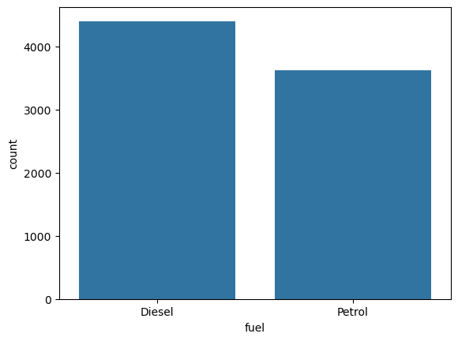

```python
# checking count of the dataframe fuel column using seaborn countplot
sns.countplot(data = df, x = 'fuel')
```

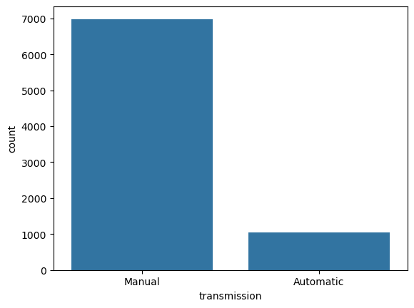

```python
sns.countplot(data = df, x = 'transmission')
```

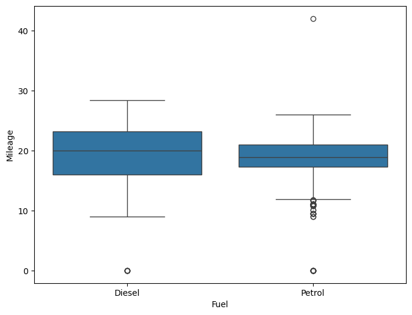

```python
# providing figure size to display
plt.figure(figsize=(8,6))
sns.boxplot(x = df['fuel'], y= df['mileage'])   # displaying fuel and mileage column in boxplot
plt.ylabel('Mileage')
plt.xlabel('Fuel')
```

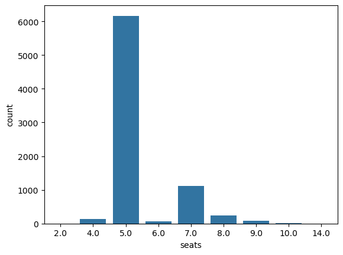

```python
sns.countplot(data = df, x = 'seats')
```

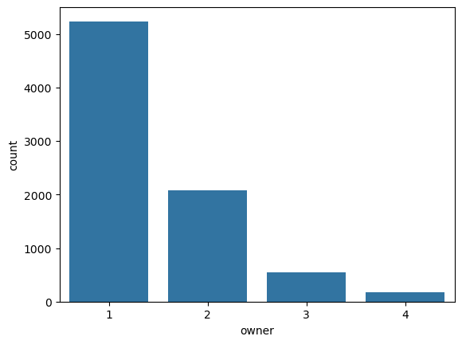

```python
sns.countplot(data = df, x = 'owner')
```

```python
df
```

|  | brand | year | sell_price | km | fuel | sell_type | transmission | owner | mileage | engine | max_power | seats |
| --- | --- | --- | --- | --- | --- | --- | --- | --- | --- | --- | --- | --- |
| 0 | Maruti | 2014 | 450000 | 145500 | Diesel | Individual | Manual | 1 | 23.40 | 1248.0 | 74.00 | 5.0 |
| 1 | Skoda | 2014 | 370000 | 120000 | Diesel | Individual | Manual | 2 | 21.14 | 1498.0 | 103.52 | 5.0 |
| 2 | Honda | 2006 | 158000 | 140000 | Petrol | Individual | Manual | 3 | 17.70 | 1497.0 | 78.00 | 5.0 |
| 3 | Hyundai | 2010 | 225000 | 127000 | Diesel | Individual | Manual | 1 | 23.00 | 1396.0 | 90.00 | 5.0 |
| 4 | Maruti | 2007 | 130000 | 120000 | Petrol | Individual | Manual | 1 | 16.10 | 1298.0 | 88.20 | 5.0 |
| ... | ... | ... | ... | ... | ... | ... | ... | ... | ... | ... | ... | ... |
| 8123 | Hyundai | 2013 | 320000 | 110000 | Petrol | Individual | Manual | 1 | 18.50 | 1197.0 | 82.85 | 5.0 |
| 8124 | Hyundai | 2007 | 135000 | 119000 | Diesel | Individual | Manual | 4 | 16.80 | 1493.0 | 110.00 | 5.0 |
| 8125 | Maruti | 2009 | 382000 | 120000 | Diesel | Individual | Manual | 1 | 19.30 | 1248.0 | 73.90 | 5.0 |
| 8126 | Tata | 2013 | 290000 | 25000 | Diesel | Individual | Manual | 1 | 23.57 | 1396.0 | 70.00 | 5.0 |
| 8127 | Tata | 2013 | 290000 | 25000 | Diesel | Individual | Manual | 1 | 23.57 | 1396.0 | 70.00 | 5.0 |

8028 rows × 12 columns

```python
print(df['fuel'].unique())
print(df['transmission'].unique())
print(df['brand'].unique())
```

```
['Diesel' 'Petrol']
['Manual' 'Automatic']
['Maruti' 'Skoda' 'Honda' 'Hyundai' 'Toyota' 'Ford' 'Renault' 'Mahindra'
 'Tata' 'Chevrolet' 'Fiat' 'Datsun' 'Jeep' 'Mercedes-Benz' 'Mitsubishi'
 'Audi' 'Volkswagen' 'BMW' 'Nissan' 'Lexus' 'Jaguar' 'Land' 'MG' 'Volvo'
 'Daewoo' 'Kia' 'Force' 'Ambassador' 'Ashok' 'Isuzu' 'Opel' 'Peugeot']
```

```python
# using scikit learn preprocessing LabelEncoder to change string data to numberic array of number [0,1,2,3] to predict y
from sklearn.preprocessing import LabelEncoder
import pickle # import pickle to save trained model and use easily when necessary

le = LabelEncoder()

df['fuel'] = le.fit_transform(df['fuel'])
print("Fuel mapping:", dict(zip(le.classes_, le.transform(le.classes_))))   # change data to numeric array [0,1,2,3] in ascending order a-z and then showing which array shows which string data for clarification

df['transmission'] = le.fit_transform(df['transmission'])
print("Transmission mapping:", dict(zip(le.classes_, le.transform(le.classes_))))

df['sell_type'] = le.fit_transform(df['sell_type'])
print("Sell Type mapping:", dict(zip(le.classes_, le.transform(le.classes_))))

df['brand'] = le.fit_transform(df['brand'])
print("Brand mapping:", dict(zip(le.classes_, le.transform(le.classes_))))

# le_brand = LabelEncoder()
# le_fuel = LabelEncoder()
# le_sell = LabelEncoder()

# 0 = Diesel, 1 = Petrol (because fit-transform transforms value as per ascending order)
# df['fuel'] = le.fit_transform(df['fuel'])
# df['transmission'] = le.fit_transform(df['transmission'])
# df['sell_type'] = le.fit_transform(df['sell_type'])
# df['brand'] = le.fit_transform(df['brand'])
# # changing variables to numeric type to make sure column values work in predict cases because only numeric value can be used in prediction
# print(df['fuel'].unique())
# print(df['transmission'].unique())
# print(df['sell_type'].unique())
# print(df['brand'].unique())


# #load Model
# pickle.dump(le_brand, open("model/le_brand.pkl", "wb"))
# pickle.dump(le_fuel, open("model/le_fuel.pkl", "wb"))
# pickle.dump(le_sell, open("model/le_sell.pkl", "wb"))
```

[output not shown]

```python
print(df['fuel'].unique())
print(df['transmission'].unique())
print(df['sell_type'].unique())
print(df['brand'].unique())
```

```
[0 1]
[1 0]
[1 0 2]
[20 27 10 11 29  9 26 19 28  4  7  6 14 21 22  2 30  3 23 17 13 16 18 31
  5 15  8  0  1 12 24 25]
```

```python
# df = df.drop(columns=['brand'])
```

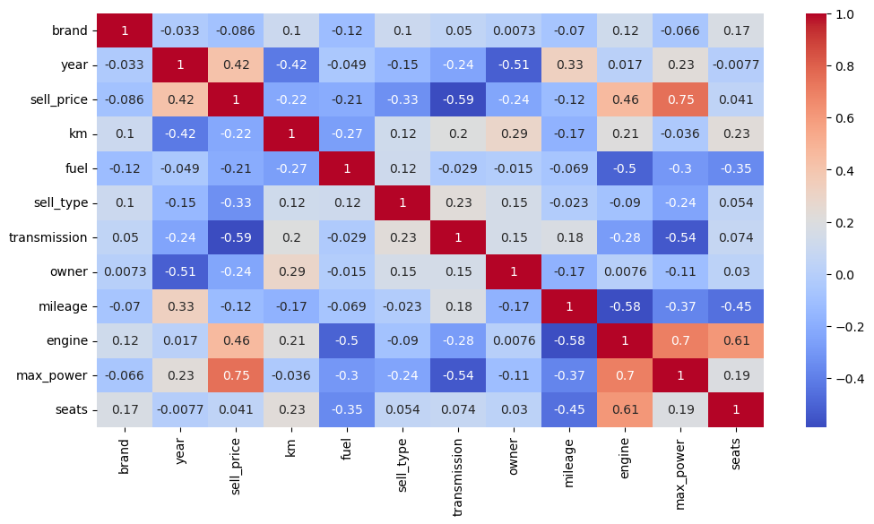

```python
plt.figure(figsize=(12,6))
sns.heatmap(df.corr(), annot=True, cmap="coolwarm") # used heatmap to see correlation and drop unnecessary column # closer to 1 better
```

```python
df = df.drop(columns=['year','transmission', 'owner'])  # dropped columns after correlation using correlation sns heatmap
df
```

|  | brand | sell_price | km | fuel | sell_type | mileage | engine | max_power | seats |
| --- | --- | --- | --- | --- | --- | --- | --- | --- | --- |
| 0 | 20 | 450000 | 145500 | 0 | 1 | 23.40 | 1248.0 | 74.00 | 5.0 |
| 1 | 27 | 370000 | 120000 | 0 | 1 | 21.14 | 1498.0 | 103.52 | 5.0 |
| 2 | 10 | 158000 | 140000 | 1 | 1 | 17.70 | 1497.0 | 78.00 | 5.0 |
| 3 | 11 | 225000 | 127000 | 0 | 1 | 23.00 | 1396.0 | 90.00 | 5.0 |
| 4 | 20 | 130000 | 120000 | 1 | 1 | 16.10 | 1298.0 | 88.20 | 5.0 |
| ... | ... | ... | ... | ... | ... | ... | ... | ... | ... |
| 8123 | 11 | 320000 | 110000 | 1 | 1 | 18.50 | 1197.0 | 82.85 | 5.0 |
| 8124 | 11 | 135000 | 119000 | 0 | 1 | 16.80 | 1493.0 | 110.00 | 5.0 |
| 8125 | 20 | 382000 | 120000 | 0 | 1 | 19.30 | 1248.0 | 73.90 | 5.0 |
| 8126 | 28 | 290000 | 25000 | 0 | 1 | 23.57 | 1396.0 | 70.00 | 5.0 |
| 8127 | 28 | 290000 | 25000 | 0 | 1 | 23.57 | 1396.0 | 70.00 | 5.0 |

8028 rows × 9 columns

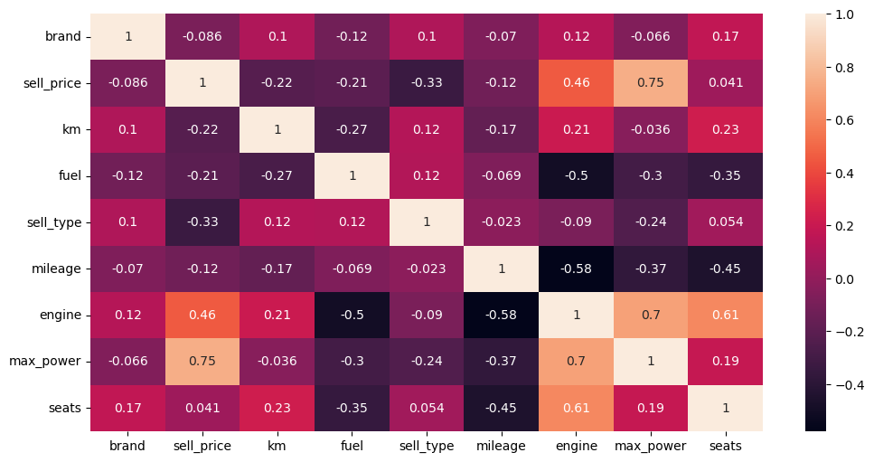

```python
plt.figure(figsize=(12,6))
sns.heatmap(df.corr(), annot=True)  # annot = annotations in figure
```

```python
# Feature Engineering

X = df[['brand', 'km', 'fuel', 'sell_type', 'mileage', 'engine', 'seats','max_power']]  # Features/Label/X/Predictor
y = df['sell_price']    # y/Target
```

```python
from sklearn.model_selection import train_test_split
X_train, X_test, y_train, y_test =  train_test_split(X,y, test_size=0.3, random_state= 42) # train_test_split to split data into train test and test size 30% data where random state 42 takes same data everytime it runs
```

```python
# Preprocessing
# Checking if value is null
X_train[['brand', 'km', 'fuel', 'sell_type', 'mileage', 'engine', 'seats','max_power']].isna().sum()
```

```
brand          0
km             0
fuel           0
sell_type      0
mileage      154
engine       154
seats        154
max_power    149
dtype: int64
```

```python
y_train.isna().sum()
```

```
np.int64(0)
```

```python
X_test.isna().sum()
```

```
brand         0
km            0
fuel          0
sell_type     0
mileage      60
engine       60
seats        60
max_power    59
dtype: int64
```

```python
# since many values null
# adding median outliers
X_train['mileage'].fillna(X_train['mileage'].median(), inplace=True)
X_train['engine'].fillna(X_train['engine'].median(), inplace=True)
X_train['seats'].fillna(X_train['seats'].median(), inplace=True)
X_train['max_power'].fillna(X_train['max_power'].median(), inplace=True)

X_test['mileage'].fillna(X_test['mileage'].median(), inplace=True)
X_test['engine'].fillna(X_test['engine'].median(), inplace=True)
X_test['seats'].fillna(X_test['seats'].median(), inplace=True)
X_test['max_power'].fillna(X_test['max_power'].median(), inplace=True)
```

```python
X_train[['brand', 'km', 'fuel', 'sell_type', 'mileage', 'engine', 'seats','max_power']].isna().sum()
```

```
brand        0
km           0
fuel         0
sell_type    0
mileage      0
engine       0
seats        0
max_power    0
dtype: int64
```

```python
def outlier_count(col, data = X_train):

    # calculate your 25% quatile and 75% quatile
    q75, q25 = np.percentile(data[col], [75, 25])

    # calculate your inter quatile
    iqr = q75 - q25

    # min_val and max_val
    min_val = q25 - (iqr*1.5)
    max_val = q75 + (iqr*1.5)

    # count number of outliers, which are the data that are less than min_val or more than max_val calculated above
    outlier_count = len(np.where((data[col] > max_val) | (data[col] < min_val))[0])

    # calculate the percentage of the outliers
    outlier_percent = round(outlier_count/len(data[col])*100, 2)

    if(outlier_count > 0):
        print("\n"+15*'-' + col + 15*'-'+"\n")
        print('Number of outliers: {}'.format(outlier_count))
        print('Percent of data that is outlier: {}%'.format(outlier_percent))
```

```python
# calling outlier function to count outliers
for col in X_train.columns:
    outlier_count(col)
```

```
---------------km---------------

Number of outliers: 102
Percent of data that is outlier: 1.82%

---------------sell_type---------------

Number of outliers: 944
Percent of data that is outlier: 16.8%

---------------mileage---------------

Number of outliers: 14
Percent of data that is outlier: 0.25%

---------------engine---------------

Number of outliers: 836
Percent of data that is outlier: 14.88%

---------------seats---------------

Number of outliers: 1158
Percent of data that is outlier: 20.61%

---------------max_power---------------

Number of outliers: 409
Percent of data that is outlier: 7.28%
```

```python
# scikit learn preprocessing StandardScaler algorithm used to scale and transform
from sklearn.preprocessing import StandardScaler

scaler = StandardScaler()
X_train = scaler.fit_transform(X_train)
X_test  = scaler.transform(X_test)
```

```python
print("Shape of X_train: ", X_train.shape)
print("Shape of X_test: ", X_test.shape)
print("Shape of y_train: ", y_train.shape)
print("Shape of y_test: ", y_test.shape)
```

```
Shape of X_train:  (5619, 8)
Shape of X_test:  (2409, 8)
Shape of y_train:  (5619,)
Shape of y_test:  (2409,)
```

```python
from sklearn.linear_model import LinearRegression   # using linear regression algorithm to test model
from sklearn.metrics import mean_squared_error, r2_score
 # using mean square error and r2 score to check error where MSE can be any number so causes issue finding error , using R square to predict closest to 1 best

lr = LinearRegression()
lr.fit(X_train, y_train)
yPred = lr.predict(X_test)

print("MSE: ", mean_squared_error(y_test, yPred))
print("r2: ", r2_score(y_test, yPred))
```

```
MSE:  238980166156.9503
r2:  0.6423908700337254
```

```python
# Cross Validation + Grid Search - Checking which model is suitable
from sklearn.linear_model import LinearRegression
from sklearn.svm import SVR
from sklearn.neighbors import KNeighborsRegressor
from sklearn.tree import DecisionTreeRegressor
from sklearn.ensemble import RandomForestRegressor


algorithms = [LinearRegression(), SVR(), KNeighborsRegressor(), DecisionTreeRegressor(random_state = 0),
              RandomForestRegressor(n_estimators = 100, random_state = 0)]

# Models
algorithm_names = ["Linear Regression", "SVR", "KNeighbors Regressor", "Decision-Tree Regressor", "Random-Forest Regressor"]
```

```python
# lowest the mean number greater accuracy algorithm
from sklearn.model_selection import KFold, cross_val_score

#lists for keeping mse
train_mse = []
test_mse = []

#defining splits
kfold = KFold(n_splits=5, shuffle=True)

for i, model in enumerate(algorithms):
    scores = cross_val_score(model, X_train, y_train, cv=kfold, scoring='neg_mean_squared_error')
    print(f"{algorithm_names[i]} - Score: {scores}; Mean: {scores.mean()}")
```

```
Linear Regression - Score: [-2.33017504e+11 -2.50085713e+11 -2.52836380e+11 -2.15329406e+11
 -2.62574948e+11]; Mean: -242768790160.712
SVR - Score: [-6.91691775e+11 -5.26685153e+11 -8.01143671e+11 -7.69024203e+11
 -5.62516834e+11]; Mean: -670212327151.9222
KNeighbors Regressor - Score: [-4.41374789e+10 -7.12703968e+10 -6.04619583e+10 -6.69145207e+10
 -8.32820446e+10]; Mean: -65213279874.65128
Decision-Tree Regressor - Score: [-4.53980095e+10 -9.44538533e+10 -6.27062677e+10 -1.10243359e+11
 -6.88182752e+10]; Mean: -76323952857.03886
Random-Forest Regressor - Score: [-2.94011169e+10 -2.48059907e+10 -4.41301871e+10 -4.18007174e+10
 -5.46396389e+10]; Mean: -38955530214.16865
```

```python
# random forest best because less
from sklearn.model_selection import GridSearchCV

param_grid = {'bootstrap': [True], 'max_depth': [5, 10, None],
              'n_estimators': [5, 6, 7, 8, 9, 10, 11, 12, 13, 15]}

rf = RandomForestRegressor(random_state = 1)

grid = GridSearchCV(estimator = rf,
                    param_grid = param_grid,
                    cv = kfold,
                    n_jobs = -1,
                    return_train_score=True,
                    refit=True,
                    scoring='neg_mean_squared_error')

# Fit your grid_search
grid.fit(X_train, y_train)
```

```
GridSearchCV(cv=KFold(n_splits=5, random_state=None, shuffle=True),
             estimator=RandomForestRegressor(random_state=1), n_jobs=-1,
             param_grid={'bootstrap': [True], 'max_depth': [5, 10, None],
                         'n_estimators': [5, 6, 7, 8, 9, 10, 11, 12, 13, 15]},
             return_train_score=True, scoring='neg_mean_squared_error')
```

```python
from sklearn.metrics import mean_squared_error, r2_score

best_rf = grid.best_estimator_

# Predict
yPred = best_rf.predict(X_test)

# Evaluation
print("Best Parameters: ", grid.best_params_)
print("MSE: ", mean_squared_error(y_test, yPred))
print("R Square: ", r2_score(y_test, yPred))
```

```
Best Parameters:  {'bootstrap': True, 'max_depth': None, 'n_estimators': 15}
MSE:  53778051425.11272
R Square:  0.9195267017732935
```

```python
# checking best grid paramters
grid.best_params_
```

```
{'bootstrap': True, 'max_depth': None, 'n_estimators': 15}
```

```python
# best Mean Square Error (MSE) grid score
best_mse = grid.best_score_
best_mse
```

```
np.float64(-37140144416.330505)
```

```python
# Testing feature importance
rf = grid.best_estimator_

rf.feature_importances_
```

```
array([0.01563404, 0.14954239, 0.00666197, 0.00500465, 0.03287881,
       0.02039684, 0.00458287, 0.76529844])
```

```
<BarContainer object of 8 artists>
```

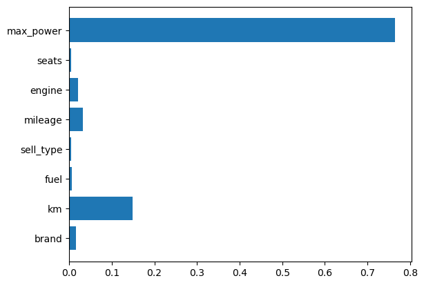

```python
# using plot checking feature importance .i.e. which feature more suitable
plt.barh(X.columns, rf.feature_importances_)
```

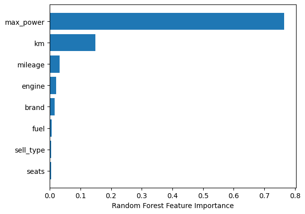

```python
# sorting feature importance
sorted_idx = rf.feature_importances_.argsort()
plt.barh(X.columns[sorted_idx], rf.feature_importances_[sorted_idx])
plt.xlabel("Random Forest Feature Importance")
```

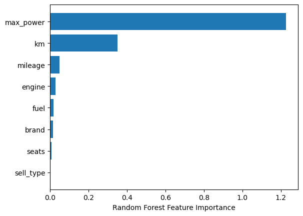

```python
# checking permutation importance from feature importance
from sklearn.inspection import permutation_importance

perm_importance = permutation_importance(rf, X_test, y_test)

#let's plot
sorted_idx = perm_importance.importances_mean.argsort()
plt.barh(X.columns[sorted_idx], perm_importance.importances_mean[sorted_idx])
plt.xlabel("Random Forest Feature Importance")
```

```python
# importing shap to check shap values
import shap

explainer = shap.TreeExplainer(rf)
shap_values = explainer.shap_values(X_test)
shap_values
```

```
array([[ -27357.04393395,   46420.44323557,  -33609.9681708 , ...,
         -41123.50174294,  -11544.65827251, -161514.06837105],
       [  14370.49201115, -184185.62286117,   34105.51599632, ...,
          65608.76469156,  -15135.84834552,  173200.17589474],
       [    808.67895293,  -65198.48649481,  -32966.35532951, ...,
         -11626.42454984,  -19176.07864822, -264403.84685037],
       ...,
       [ -18364.56826239,   84938.42368942,  -16405.3652584 , ...,
         -20151.61289766,  -25933.91927101, -413764.88105811],
       [  16961.03753411,  130454.28669583,   55214.38808812, ...,
         -14602.91986752,  -10654.56273411,  -62541.31587635],
       [  -8558.8137263 ,  142077.31236595,  -18560.16171573, ...,
         -21801.30642687,   -9449.49387753, -509548.69791831]])
```

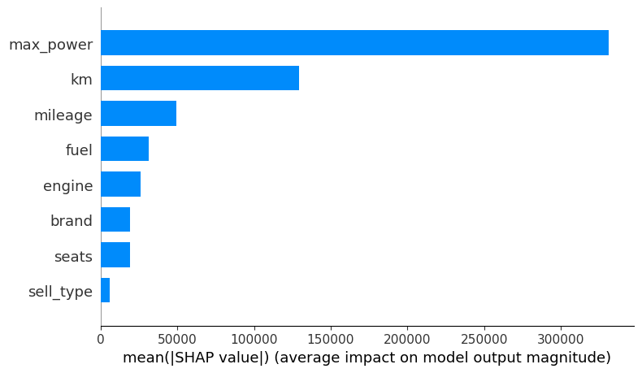

```python
shap.summary_plot(shap_values, X_test, plot_type="bar", feature_names = X.columns)
```

```python
# Inference
# Save Model
import pickle

filename = 'model/carPricePrediction.model'
pickle.dump(grid, open(filename, 'wb'))
```

```python
loaded_model = pickle.load(open(filename, 'rb'))
```

```python
df[['brand', 'km', 'fuel', 'sell_type', 'mileage', 'engine', 'seats','max_power']].loc[1]
```

```
brand            27.00
km           120000.00
fuel              0.00
sell_type         1.00
mileage          21.14
engine         1498.00
seats             5.00
max_power       103.52
Name: 1, dtype: float64
```

```python
# providing data set sample to predict result
# sample = np.array([[27,120000,0,1,21.14,1498,5,103]])
sample = np.array([[1,145500,0,1,23.4,1248,5,74]])
```

```python
# finally car price is predicted
predicted_Car_Price = loaded_model.predict(sample)
predicted_Car_Price
```

```
array([1868666.66666667])
```

Report on Car Price Prediction

Firstly, I used Linear Regression and tested the model with accuracy and got really bad accuracy R square being around 0.64 then I used Cross validation and Grid Search to get which Model best works as per my data. Then Random Forest had the highest accuracy which is around 0.91 so I prefered using Random Forest Regressor Model to predict my data and also I checked data to make sure its working mechanism. The result I got was pretty good so I used Random Forest Regressor Algorithm. Linear Regressor is mainly used in Linear data like feature and price but car pricing is non-linear data that is why Random Forest Regressor have better result.

Finally, explaining whole step in conclusion in brief, I imported data from 'Cars.csv' file cleaned ta data set filled the null value or delete rows if less null data set, dropped unwanted rows for example as per question LPG gas, CPG gas had different mileage system so its required to delete those data with LPG and CPG so I did to clean my data set and so on test drive cars were expensive thats why I deleted those row as well. Then remove every unit changed to float and LabelEncoded datas because Prediction work only on numeric values. Then split using train_test_split, gave 30% test data and remaining 70% for training. Then used Linear Regression and test model using (MSE) Mean Square Error and R Square where accuracy was not what we expected was poor accuracy around 0.64 so used Cross Validation and Grid Search to test which model works better. As per the result RandomForestRegressor worked better with around 0.91 accuracy R square which is close to 1 so I preffered using RandomForest and at last exported/saved model using pickle. As I checked feature importance where max_power was on top which affect most prices of car and sell_type had lowest feature importance among features I selected. Then I worked on deploying model using plotly(python data visualization library). Here I created form to take user data and as per that data car price is predicted.